# Molecular Heatmap - Exact Feature Match

Jordan Lee

1/12/2021

# TMP GDAN working group

## Figure 4 Suggestion

### Question

We see (in other figures) that different teams have similar high classification performance. Is this similar performance due to selection of the same feature sets?

### Rationale

If we see teams picking different features, this suggests that there are multiple biomarkers that can predict cancer subtype well. An alternative explanation if we see teams picking different features, is that perhaps there is some relationship (correlation, biological pathway connection, etc.) between features so in a sense the teams are picking the “same” features if they are correlated.

In this analysis we will address the first part: are groups picking the same features?

- `TODO:` And we will dabble in exploring feature relationships (through dissimilarity). From clustering on a dissimilarity matrix.

### Analysis

The preprocessing and generation of these files was conducted in a custom python pipeline. A summary of the pipeline is:

1. Pick a cancer cohort (here we picked breast cancer)
2. Select the best model from each of the 5 teams (JadBIO, SubSCOPE, AKLIMATE, Sci-Kit Grid, and Cloud Forest). Based on highest mean overall weighted F1 score
3. Pull the corresponding feature set from each model
4. Map features to molecular file (based on Theo’s tarball)
5. Cluster feature rows, no clustering of sample columns. Clustering done on molecular file

Note in calculating z-scores, NAs were omitted

```r
###### Hardcoded
outdir ='../data/figure_panel_b/'
# note hardcoded output file names for now

cancer <- 'BRCA'
df <- fread('../data/figure_panel_b/BRCA_fts_by_VALUE.tsv') %>% as.data.frame()
df_fts <- fread('../data/figure_panel_b/BRCA_fts_by_TEAM.tsv')%>% as.data.frame()
mappings <- fread('../data/figure_panel_b/hallmarks.tsv') %>% as.data.frame()
######
```

### Heatmaps for each data type

Scaling data - METH, GEXP, and MIR

Non-scaled data - MUTA, CNVR

I want to see the differences between features. Data was scaled - all samples for a given feature have mean 0 and sd 1. then ran through normal pipeline

```r
##### hardcoded
yes_scale <- c('N:METH' , 'N:GEXP','N:MIR') # which fts to scale
#####
```

**Code and figures**

```r
# Set up saving fig packet
setwd(outdir)
####
# Main
####
pre <- c('N:METH','N:MIR', 'I:CNVR', 'B:MUTA', 'N:GEXP') # GEXP must be last

for (prefix in pre){
  # A. Order by subtype
  df_transform <- df %>% arrange(Labels)

  # B. Column annotation
  subtype_ha <- rowAnnotation(
    Subtype = df_transform$Labels,
    na_col = 'grey',
    col = list(
      Subtype = c(
        "BRCA_1" = 'orange',
        "BRCA_2"='sienna1',
        "BRCA_3"='red',
        "BRCA_4"='red4'
      )
    ),
    show_annotation_name = FALSE
  )

  # C. Select data type
  df_transform <- df_transform %>%
      select(-Labels) %>%
      select(-all_of(cancer)) %>%
      select(starts_with(prefix))
  mat <- df_transform %>%
      as.matrix() %>%
      t()
  print(prefix)
  n_fts <- nrow(mat)
  print(n_fts)

  # 1. Heatmap that applies clustering we want
  #    second heatmap same row/col order but with added annotation bars

  # scale if appropriate
  if (prefix %in% yes_scale){
    mat <- scale(t(mat), center=TRUE, scale=TRUE) #each ft row will have mean 0, sd 1. omit NAs
  } else {
    mat <- t(mat) #flip for heatmap looks
  }

  fig <- Heatmap(
    mat,
    name = 'first heatmap',
    cluster_rows = FALSE,
    clustering_distance_columns = "euclidean",
    clustering_method_columns = "ward.D",
    cluster_columns = TRUE,
    show_row_names = FALSE,
    show_column_names = FALSE,
    column_title = 'Samples',
    row_title = 'Features',
    right_annotation = subtype_ha
  )
  # draw(fig) # dont need to draw


  ####
  # Add team annotation bar
  ####
  # Ordering
  # 1. Get order of features post heatmap clustering
  heatmap_order <- column_order(fig) # index vector
  ftnames_order <- c() # featurename vector
  for (i in heatmap_order){
    add_ft <- colnames(mat)[i]
    ftnames_order <- c(ftnames_order, add_ft)
  }
  # print(ftnames_order)
  # 2. Get new matrix that is ordered by heatmap clustering
  mat2 <- mat[,match(ftnames_order, colnames(mat))]



  # Build annotation bars of teams feature sets.
  # 1. df of all teams. match ft order in heatmap
  team_df<- df_fts %>% filter(featureID %in% ftnames_order) %>% arrange(match(featureID, ftnames_order))
  # 2. Pull just the team of interest
  jadbio <- team_df %>% pull('gnosis_1_BRCA') %>% as.character()
  cforest <- team_df %>% pull('CF|All_Top 100_BRCA') %>% as.character()
  aklimate <- team_df %>% pull('AKLIMATE_BRCA_reduced_model_1000_feature_set_BRCA') %>% as.character()
  subscope <- team_df %>% pull('nn_jg_2020-03-20_top1kfreq:BRCA_BRCA') %>% as.character()
  skgrid <- team_df %>% pull('fbedeBIC_BRCA') %>% as.character()
  team_list <- HeatmapAnnotation(
    JadBIO = jadbio,
    CForest = cforest,
    AKLIMATE = aklimate,
    SubSCOPE = subscope,
    SKGrid = skgrid,
    col = list(
      JadBIO = c('0' = "#333333", '1' = "palevioletred1"),
      CForest =  c('0' = "#333333", '1' = "mediumpurple1"),
      AKLIMATE =  c('0' = "#333333", '1' = "cadetblue1"),
      SubSCOPE =  c('0' = "#333333", '1' = "palegreen2"),
      SKGrid =  c('0' = "#333333", '1' = "rosybrown2")
    ),
    show_legend = FALSE,
    ct= anno_barplot(team_df$Total, bar_width = 1)
  )

  # 3. Heatmap
  # Set up saving fig packet
  pdf(paste('ht_base_', unlist(strsplit(prefix, ':'))[2],'.pdf',sep=''), onefile=FALSE)
  fig <- Heatmap(
    mat2, #each col will have mean 0, sd 1
    name = prefix,
    cluster_rows = FALSE,
    clustering_distance_columns = "euclidean",
    clustering_method_columns = "ward.D",
    cluster_columns = TRUE,
    show_row_names = FALSE,
    show_column_names = FALSE,
    column_title = 'Samples',
    row_title = 'Features',
    right_annotation = subtype_ha,
    top_annotation = team_list,
  )
  draw(fig)
  dev.off()


  #####
  # unit tests
  #####
  # sanity check 1 - that the row orders are the same in the two heatmaps
  assert('Assertion Error: order of feature rows on heatmap and final heatmap not same', colnames(mat2) == ftnames_order)
  # sanity check 2 - directly compare heatmap rows
  heatmap_order <- column_order(fig) # index vector
  ftnames_order2 <- c() # featurename vector
  for (i in heatmap_order){
    add_ft <- colnames(mat2)[i]
    ftnames_order2 <- c(ftnames_order2, add_ft)
  }
  assert('Assertion Error: order of feature rows on heatmap and final heatmap not same', ftnames_order2 == ftnames_order)

  print(paste('Distance metric = ', fig@row_dend_param$distance, '. Method = ', fig@row_dend_param$method, sep=' '))
}
```

```
## [1] "N:METH"
## [1] 30
```

```
## [1] "Distance metric =  euclidean . Method =  complete"
## [1] "N:MIR"
## [1] 14
```

```
## [1] "Distance metric =  euclidean . Method =  complete"
## [1] "I:CNVR"
## [1] 18
```

```
## [1] "Distance metric =  euclidean . Method =  complete"
## [1] "B:MUTA"
## [1] 7
```

```
## [1] "Distance metric =  euclidean . Method =  complete"
## [1] "N:GEXP"
## [1] 1682
```

```
## [1] "Distance metric =  euclidean . Method =  complete"
```

### Explore the hallmarks associated with GEXP features

One annotation bar (top hallmarks only, all others are not colored)

**1. Explore Hallmarks**

```r
# Prep

# look up if in hallmark mappings table
n_hallmarks <- c() # exploratory
pooled_hallmarks <- c() # exploratory
for (feature in ftnames_order){
  # 1. Preprocess - to gene symbol
  GENE <- unlist(strsplit(feature, '::'))[2]
  GENE <- unlist(strsplit(GENE, ':'))[1]
  # 2. Hallmark Mapping
  halls <- mappings[mappings$human_gene_symbol==GENE,]$gs_name %>% as.vector()
  # Multiple Hallmarks
  n_hallmarks <- c(n_hallmarks, length(halls))
  pooled_hallmarks <- c(pooled_hallmarks, halls)
}
```

```r
# How many hallmarks is a feature associated with?
# Set up saving fig packet
setwd(outdir)
pdf(paste('hallmark_fts_', unlist(strsplit(prefix, ':'))[2],'.pdf',sep=''), onefile=FALSE)

df <- table(n_hallmarks) %>% as.data.frame()
colnames(df)<- c('nHallmarks', 'Freq')
ggplot(data=df, aes(x=nHallmarks, y=Freq, fill='blue')) +
  geom_bar(stat='identity') +
  geom_text(aes(label=Freq), vjust=-0.3, size=3.5) +
  ggtitle('Histogram - How many hallmarks is a feature associated with?') +
  theme(legend.position = "none")
dev.off()
```

```r
# What hallmarks are fts most often associated with?
# Set up saving fig packet
setwd(outdir)
pdf(paste('hallmark_hist_', unlist(strsplit(prefix, ':'))[2],'.pdf',sep=''), onefile=FALSE)

df <- sort(table(pooled_hallmarks), decreasing=T) %>% as.data.frame()
colnames(df)<- c('Hallmarks', 'Freq')
ggplot(data=df, aes(x=Hallmarks, y=Freq, fill='blue')) +
  geom_bar(stat='identity') +
  geom_text(aes(label=Freq), hjust=-0.5, size=1.5) +
  ggtitle('What hallmarks are fts most often associated with') +
  theme(text = element_text(size=6)) +
  theme(legend.position = "none") +
  coord_flip()
dev.off()
```

**2. Heatmap with Hallmarks (Top 5)**

```r
####
# function
####
build_hallmark_vect <- function(hallmark, ftnames_order){
  fts_checked <- c() # sanity check
  hallmark_present <- c()
  for (feature in ftnames_order){
    # 1. Preprocess - to gene symbol
    GENE <- unlist(strsplit(feature, '::'))[2]
    GENE <- unlist(strsplit(GENE, ':'))[1]

    # 2. Hallmark Mapping
    halls <- mappings[mappings$human_gene_symbol==GENE,]$gs_name %>% as.vector()
    # If hallmark present
    if (hallmark %in% halls){
      i <- match(hallmark, halls)
      hallmark_present <- c(hallmark_present, 1)
      fts_checked <- c(fts_checked, feature)
    }
    else {
      hallmark_present <- c(hallmark_present, 0)
      fts_checked <- c(fts_checked, feature)
    }
  }
  return(hallmark_present)
}
```

```r
# Get top data
hallmark_data <- sort(table(pooled_hallmarks), decreasing=T)

# Find top hallmarks
print('Heatmap below will use these hallmarks (order matches with heatmap)')
```

```
## [1] "Heatmap below will use these hallmarks (order matches with heatmap)"
```

```r
top <- hallmark_data[1:5]
print(top)
```

```
## pooled_hallmarks
## ESTROGEN_RESPONSE_EARLY  ESTROGEN_RESPONSE_LATE             E2F_TARGETS
##                      85                      84                      79
##          G2M_CHECKPOINT        MTORC1_SIGNALING
##                      76                      57
```

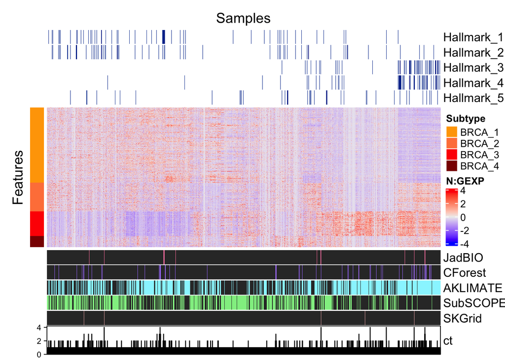

```r
top <- names(top)

vals_1 <- build_hallmark_vect(top[1],ftnames_order)
vals_2 <- build_hallmark_vect(top[2],ftnames_order)
vals_3 <- build_hallmark_vect(top[3],ftnames_order)
vals_4 <- build_hallmark_vect(top[4],ftnames_order)
vals_5 <- build_hallmark_vect(top[5],ftnames_order)


# Build heatmap
hall_annot <- HeatmapAnnotation(
  Hallmark_1 = vals_1,
  Hallmark_2 = vals_2,
  Hallmark_3 = vals_3,
  Hallmark_4 = vals_4,
  Hallmark_5 = vals_5,
  col = list(
    Hallmark_1 = c('0' = "white", '1' = "#003399"),
    Hallmark_2 = c('0' = "white", '1' = "#003399"),
    Hallmark_3 = c('0' = "white", '1' = "#003399"),
    Hallmark_4 = c('0' = "white", '1' = "#003399"),
    Hallmark_5 = c('0' = "white", '1' = "#003399")
  ),
  show_legend = FALSE
)

# Build annotation bars of teams feature sets.
# 1. df of all teams. match ft order in heatmap
team_df<- df_fts %>% filter(featureID %in% ftnames_order) %>% arrange(match(featureID, ftnames_order))
# 2. Pull just the team of interest
jadbio <- team_df %>% pull('gnosis_1_BRCA') %>% as.character()
cforest <- team_df %>% pull('CF|All_Top 100_BRCA') %>% as.character()
aklimate <- team_df %>% pull('AKLIMATE_BRCA_reduced_model_1000_feature_set_BRCA') %>% as.character()
subscope <- team_df %>% pull('nn_jg_2020-03-20_top1kfreq:BRCA_BRCA') %>% as.character()
skgrid <- team_df %>% pull('fbedeBIC_BRCA') %>% as.character()
team_hallmark <- HeatmapAnnotation(
  JadBIO = jadbio,
  CForest = cforest,
  AKLIMATE = aklimate,
  SubSCOPE = subscope,
  SKGrid = skgrid,
  col = list(
    JadBIO = c('0' = "#333333", '1' = "palevioletred1"),
    CForest =  c('0' = "#333333", '1' = "mediumpurple1"),
    AKLIMATE =  c('0' = "#333333", '1' = "cadetblue1"),
    SubSCOPE =  c('0' = "#333333", '1' = "palegreen2"),
    SKGrid =  c('0' = "#333333", '1' = "rosybrown2")
  ),
  show_legend = FALSE,
  ct= anno_barplot(team_df$Total, bar_width = 1)
)


fig <- Heatmap(
  mat2, #each col will have mean 0, sd 1
  name = prefix,
  cluster_rows = FALSE,
  cluster_columns = FALSE,
  show_row_names = FALSE,
  show_column_names = FALSE,
  column_title = 'Samples',
  row_title = 'Features',
  left_annotation = subtype_ha,
  bottom_annotation = team_hallmark,
  top_annotation = hall_annot
)
# Set up saving fig packet
# setwd(outdir)
# pdf(paste('ht_top5_', unlist(strsplit(prefix, ':'))[2],'.pdf',sep=''), onefile=FALSE)
draw(fig)
```

```r
# dev.off()
```

**WIP 3. Heatmap with Hallmarks (Top 10)**

first set how many hallmarks want. **Note will need to manualy update the `rowAnnotation()` to reflect these n results. currently set to 10**

```r
#### harcoded
how_many_halls <- 10
# TODO update rowAnnotation to auto update with this
#####
```

```r
# Build annot objects for heatmap
color_list <- list() # init
for (i in 1:how_many_halls){
  # 1. Create vectors for each hallmark
  varname <- paste('vals', i, sep='_')
  assign(varname, build_hallmark_vect(names(hallmark_data[i]),ftnames_order))

  # 2.  Create color assignments for each hallmark
  varname <- paste('Hallmark', i, sep='_')
  color_list[[varname]] <- c('0' = "white", '1' = "black")

  # 3. build last obj type for rowAnnotation()
  # wip, hardcoded below for now
}

# Build heatmap
# TODO loop through to assign these as in #3 above
hall_annot <- HeatmapAnnotation(
  Hallmark_1 = vals_1,
  Hallmark_2 = vals_2,
  Hallmark_3 = vals_3,
  Hallmark_4 = vals_4,
  Hallmark_5 = vals_5,
  Hallmark_6 = vals_6,
  Hallmark_7 = vals_7,
  Hallmark_8 = vals_8,
  Hallmark_9 = vals_9,
  Hallmark_10 = vals_10,
  col = color_list,
  show_legend = FALSE
)

fig <- Heatmap(
  mat2, #each col will have mean 0, sd 1
  name = prefix,
  cluster_rows = FALSE,
  cluster_columns = FALSE,
  show_row_names = FALSE,
  show_column_names = FALSE,
  column_title = 'Samples',
  row_title = 'Features',
  right_annotation = subtype_ha,
  top_annotation = team_list,
  bottom_annotation = hall_annot,
)
# Set up saving fig packet
setwd(outdir)
pdf(paste('ht_top10_', unlist(strsplit(prefix, ':'))[2],'.pdf',sep=''), onefile=FALSE)
draw(fig)
dev.off()
```